# Day 1, Session 3: Data Visualization in R

## Layer: axes

- Defining the axis range:

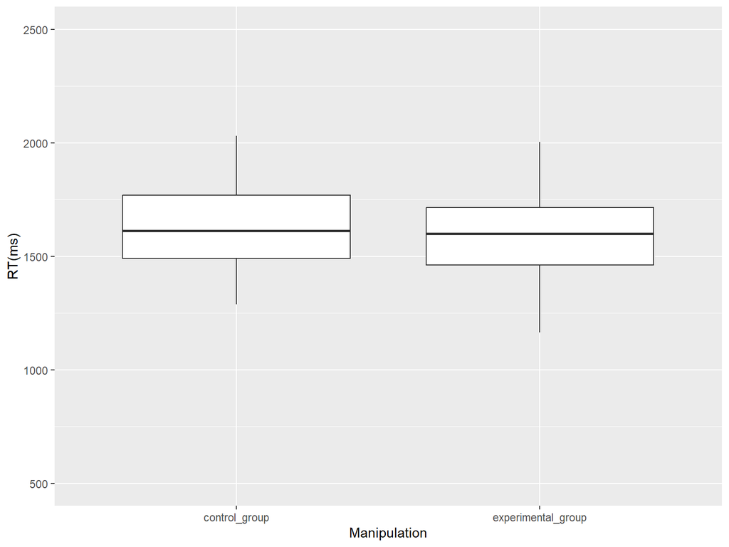

```r
g11 + coord_cartesian(ylim = c(500, 2500))
```

## Layer: axes

- Rotating the plot

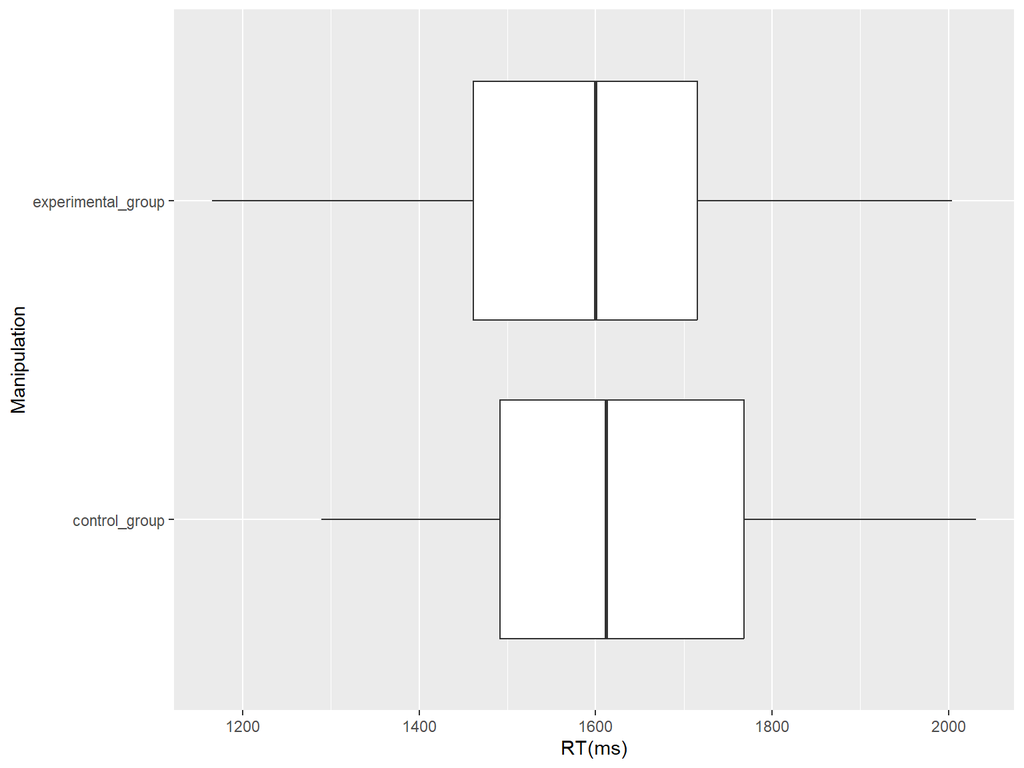

```r
g11 + coord_flip()
```

## Coordinate systems

- Code showing what a line and a rectangle look like in a polar coordinate system
  - Borrowed from Wickham (2015)

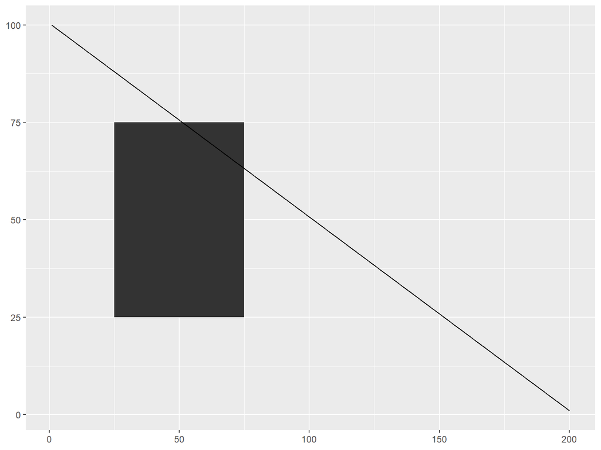

```r
rect <- data.frame(x = 50, y = 50)
line <- data.frame(x = c(1, 200), y = c(100, 1))
base <- ggplot(mapping = aes(x, y)) +
geom_tile(data = rect, aes(width = 50, height = 50)) +
geom_line(data = line) +
xlab(NULL) + ylab(NULL)
base
```

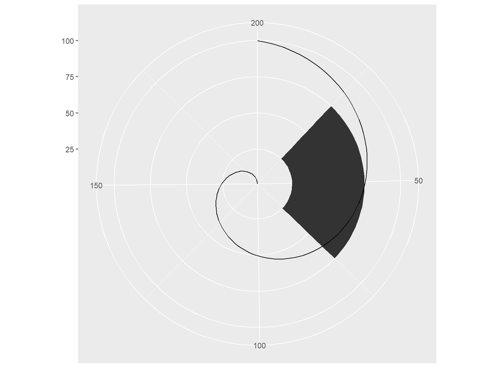

```r
base + coord_polar("x")
```

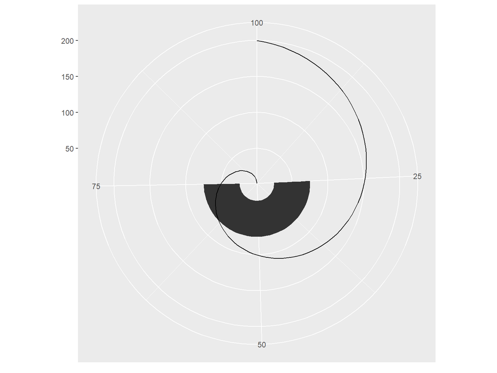

```r
base + coord_polar("y")
```

## Layer: themes

## Layer: themes

- Let’s change the theme: classic

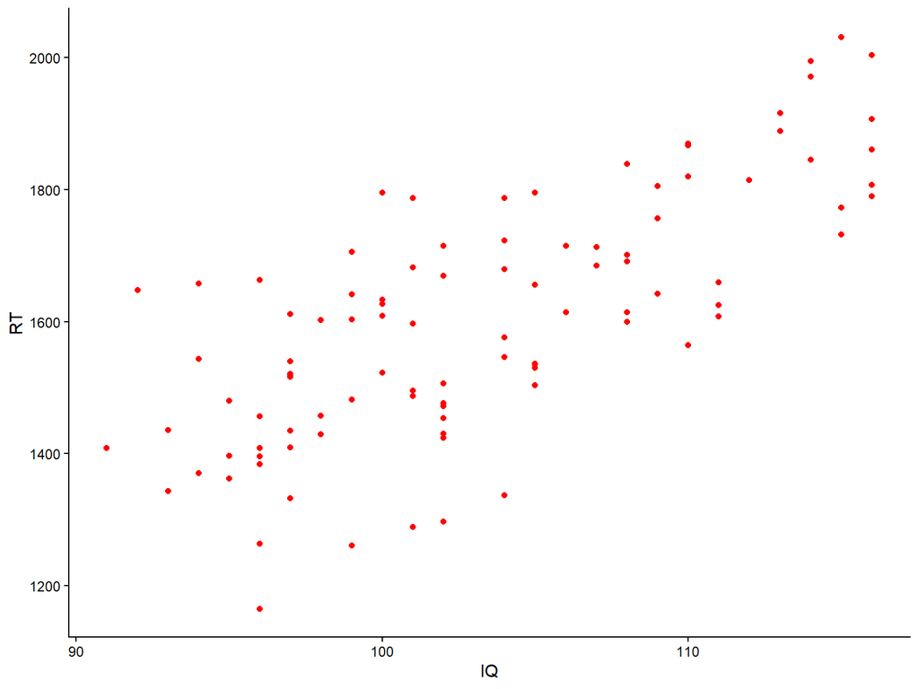

```r
g2 + theme_classic()
```

## Layer: themes

- let’s change the theme: minimal

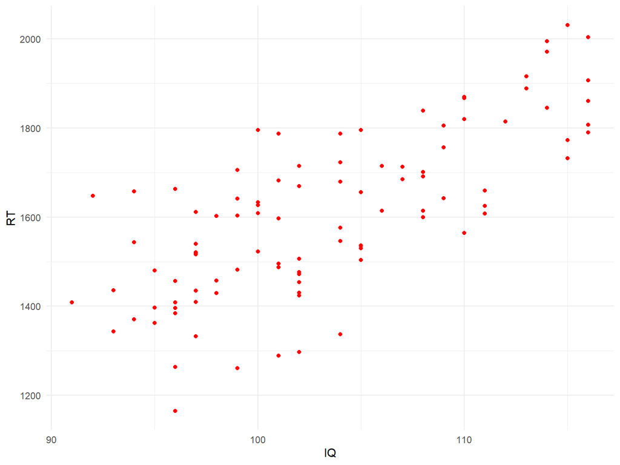

```r
g2 + theme_minimal()
```

## Layer: themes

- There’s more
  - In addition the basic themes, there’s also the ggthemes package with an even wider selection

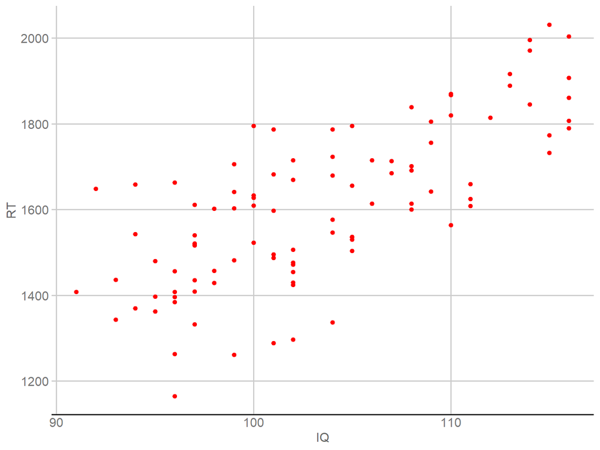

```r
library(ggthemes)
g2 + theme_gdocs()
```

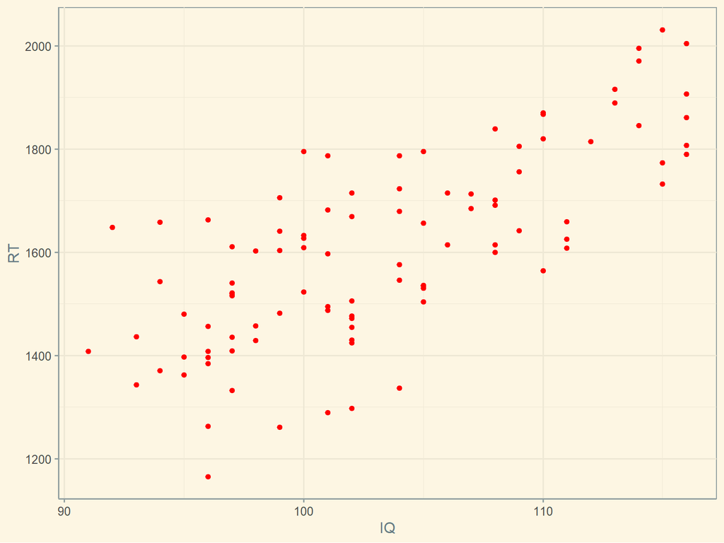

```r
g2 + theme_solarized()
```

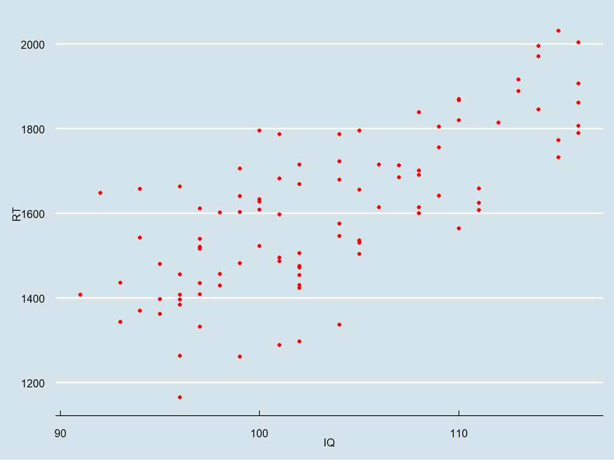

```r
g2 + theme_economist()
```

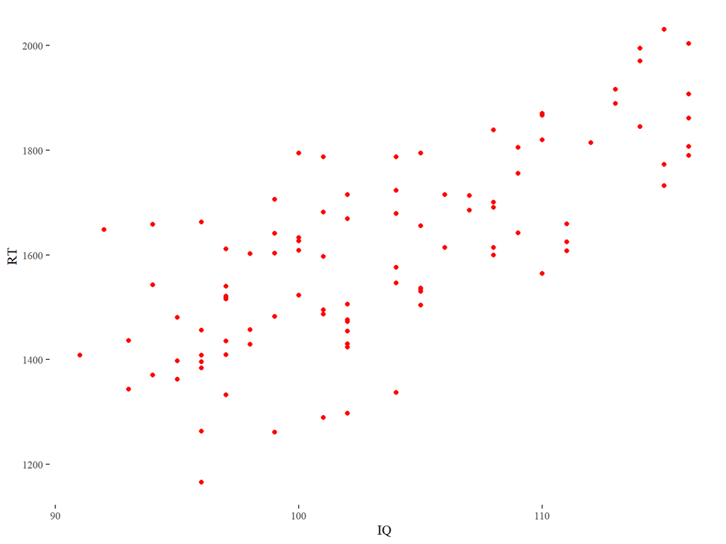

```r
g2 + theme_tufte()
```

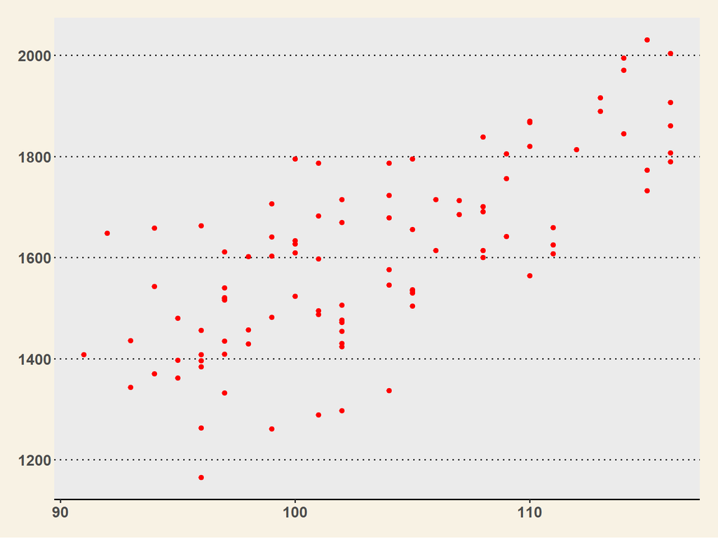

```r
g2 + theme_wsj()
```

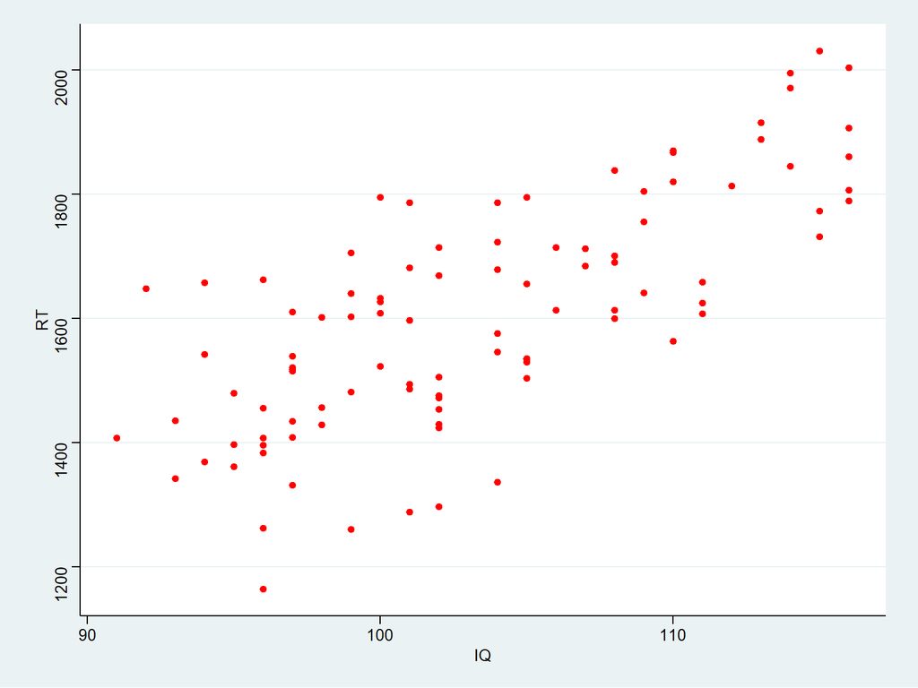

```r
g2 + theme_stata()
```

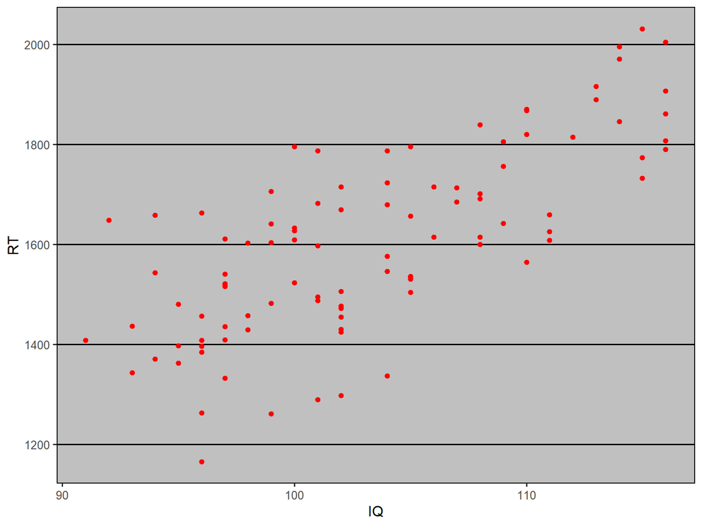

```r
g2 + theme_excel()
```

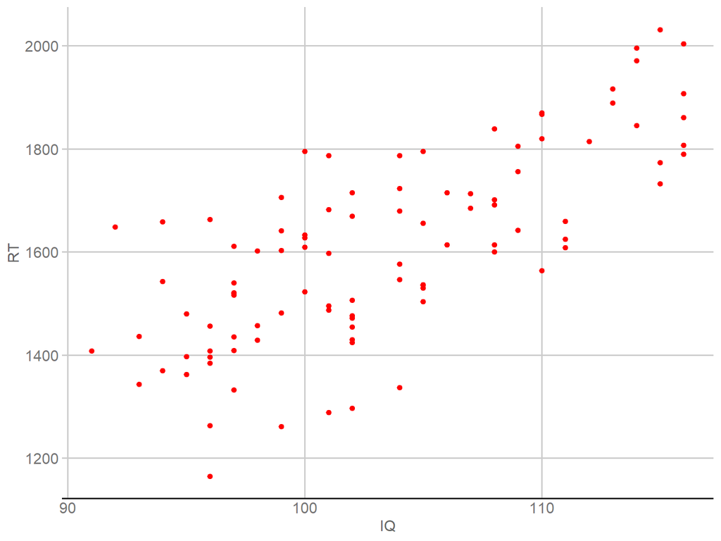

```r
g2 + theme_gdocs()
```

## Layer: themes

- since we’re already playing with theme elements,
- for browsing at home:

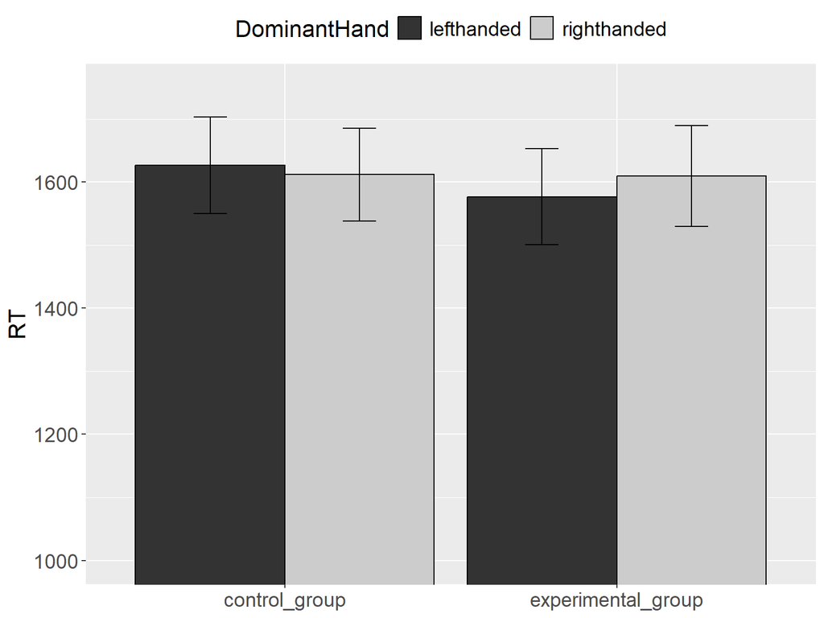

```r
ggplot(data=df, aes(x=Manipulation, y=RT, fill=DominantHand)) +
  coord_cartesian(ylim = c(1000, 1750)) +
  stat_summary(fun = mean, geom = "bar", position = "dodge", color="black") +
   scale_fill_grey() +
   scale_x_discrete(limits=c("control_group", "experimental_group")) +
   theme(axis.title.y = element_text(size=16), axis.title.x = element_blank()) +
   theme(axis.text.x = element_text(size=14), axis.text.y = element_text(size=14)) +
   theme(legend.title = element_text(size=16)) +
   theme(legend.text = element_text(size=14)) +
   theme(legend.position = "top") +
  stat_summary(fun.data = mean_cl_normal, geom = "errorbar",
               position = position_dodge(width = 0.90), width = 0.2)
```

## Let’s save the plot as an image:

```r
ggsave("Figure2.jpeg", width = 5, height = 5, dpi = 300)
```

## Let’s combine several plots into one panel and save it as a single image:

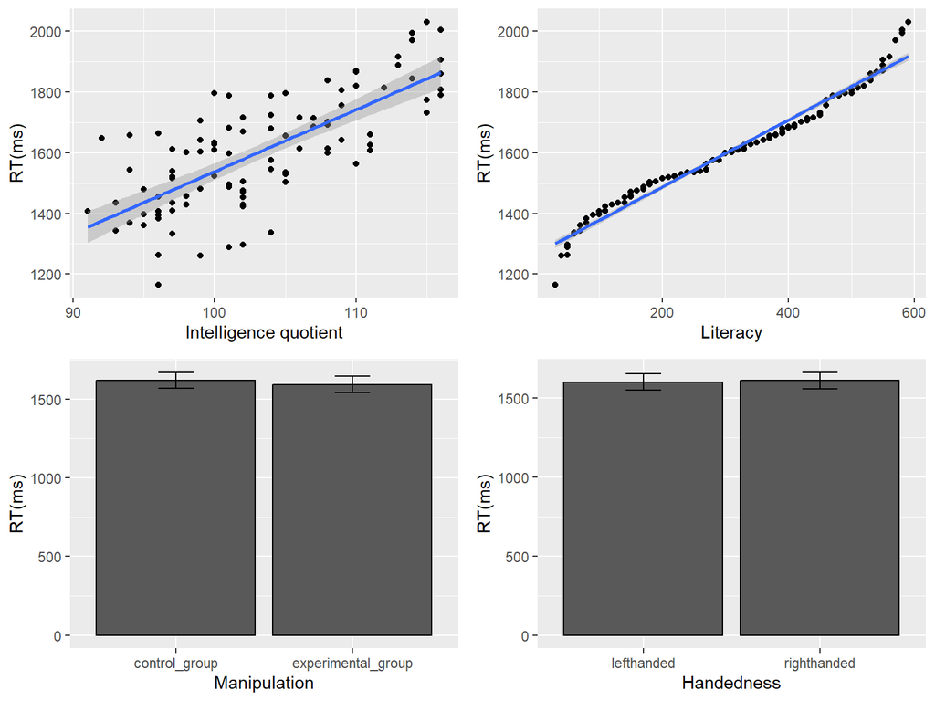

```r
a1 = ggplot(df, aes(x=IQ, y=RT)) +
  geom_point() +
  xlab("Intelligence quotient") +
  ylab("RT(ms)") +
  geom_smooth(method = "lm", se = TRUE)


a2 = ggplot(df, aes(x=ReadingExperience, y=RT)) +
  geom_point() +
  xlab("Literacy") +
  ylab("RT(ms)") +
  geom_smooth(method = "lm", se = TRUE)



b1 = ggplot(df, aes(x=Manipulation, y=RT)) +
  stat_summary(fun = mean, geom = "bar", position = "dodge", color="black") +
  stat_summary(fun.data = mean_cl_normal, geom = "errorbar",
               position = position_dodge(width = 0.90), width = 0.2) +
  xlab("Manipulation") +
  ylab("RT(ms)")

b2 = ggplot(df, aes(x=DominantHand, y=RT)) +
  stat_summary(fun = mean, geom = "bar", position = "dodge", color="black") +
  stat_summary(fun.data = mean_cl_normal, geom = "errorbar",
               position = position_dodge(width = 0.90), width = 0.2) +
  xlab("Handedness") +
  ylab("RT(ms)")


library(gridExtra)

My_panel = grid.arrange(a1, a2, b1, b2, nrow = 2)
```

```r
ggsave("Panel_of_Plots.jpeg", My_panel, width = 10, height = 10, dpi = 300)
```

- But also (and more popular recently)

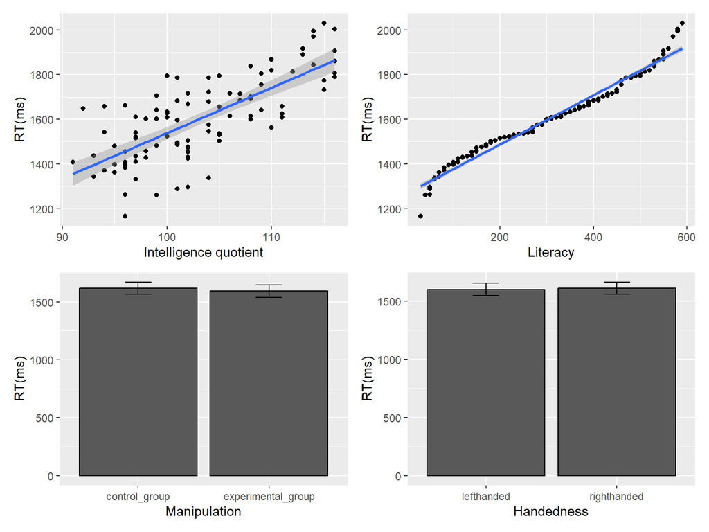

```r
library(patchwork)
a1 + a2 + b1 + b2
```

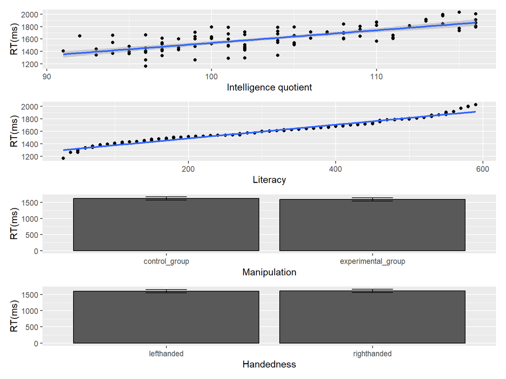

```r
a1 / a2 / b1 / b2
```

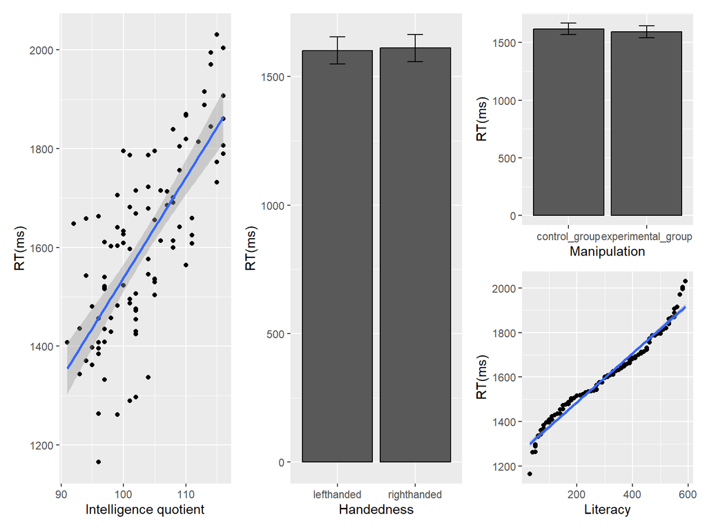

```r
a1 | b2 | b1 / a2
```

## Many more possibilities exist

- Various data transformations
- Adding text to a desired location on the plot
- Changing the arrangement of plot elements
- Animated and interactive plots!
- Even programming within ggplot!

## For everything you don’t know by heart (i.e. for most things):

- Google a phrase describing what you want to accomplish (plenty of blogs out there)
- Use the cheatsheets
  - https://raw.githubusercontent.com/rstudio/cheatsheets/main/data-visualization.pdf
- Vibe code! :)